# GumGum Ad Impression Forecast Presentation by Bohan Zhang

To run this R markdown script, you need to have library `forecast` and `e1071` installed. you can get the two libraries installed by the following command:

- install.packages(‘forecast’,repos=“http://cran.us.r-project.org”)
- install.packages(‘e1071’,repos=“http://cran.us.r-project.org”)

Also, you need to put data file `training` and `validation` in a folder named `input` under your working directory. you can get your current working directory by `getwd()`.

### I. Overview

This is a presentation for GumGum’s programming assignment.

This assignment aims to forecast ad impression numbers on GumGum’s affiliated websites in the next 30 days based on the past 365 days data.

- `Seasonal naive` model
- `Linear regression` model with trend and seasonal dummy variables (day of week)
- `SVM regression` with trend and seasonal dummy variables (day of week)
- `STL + ETS/Arima` model
- `Arima` model

Now let’s take a look at the details:

These are the packages we will use in this project:

- library `forecast` provides forecasting functions for **Time Series** and **Linear Models**.
- library `e1071` provides fucntions for **Support Vector Machines (SVM)**.

```r
library(forecast)
library(e1071)
```

### II. Data Exploration

Read the train and validation data:

```r
train <- read.table("./input/training")
validation  <- read.table("./input/validation")
```

First, let’s take a look at the data.

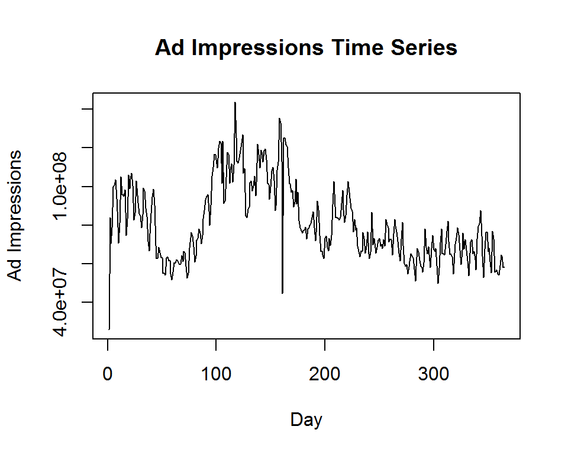

```r
s <- ts(train) # convert the list of numbers to a time series
plot(s, xlab='Day',ylab='Ad Impressions',main='Ad Impressions Time Series')
```

It can be observed that the data has very obvious **seasonal pattern** and slightly downward **trend pattern**.

Let’s zoom in:

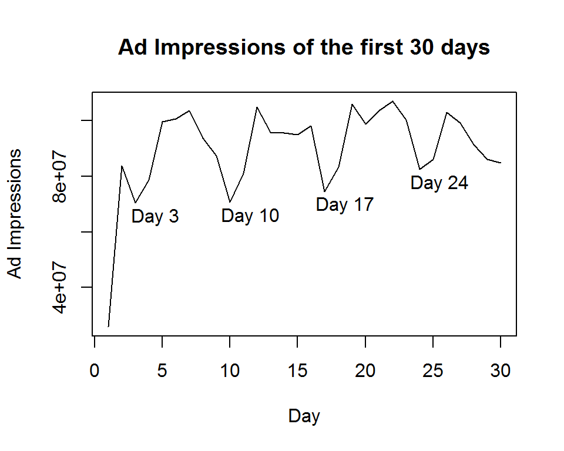

A **weekly pattern** can be observed. Therefore, in the following analysis, we should try to construct our model based on seasonal models with weekly pattern.

### III.Model Construction

#### 1. Metrics

To begin with, we need to be clear how we want to select the best model.

To evaluate the performance of each forecast model, we consider two metrics:

- `RMSPE` (Root Mean Square Percentage Error)
- `RMSE` (Root Mean Square Error)

Defined as follow:

```r
RMSPE <- function(val, pred){
  err <- sqrt(mean((pred/val-1)^2))
  return(err)
}
```

```r
RMSE <- function(val,pred){
  err <- sqrt(mean((pred-val)^2))
  return(err)
}
```

#### 2. Models

##### 1) Seasonal Naive Model

The first model we considered is a `seasonal naive` model, which uses the last 7 days observation as forecasts. The last 7 days obervations are used to reflect the seaonal (weekly) pattern.

```r
seasonal.naive <- function(train){
  # Computes seasonal naive forecats
  #
  # Set each forecast to be equal to the value of the same weekday
  # of the last observed 7 days

  horizon <- 30  # period to forecast
  fc <- train[rep_len(nrow(train) - (7:1) + 1,horizon),]

  return(fc)
}
```

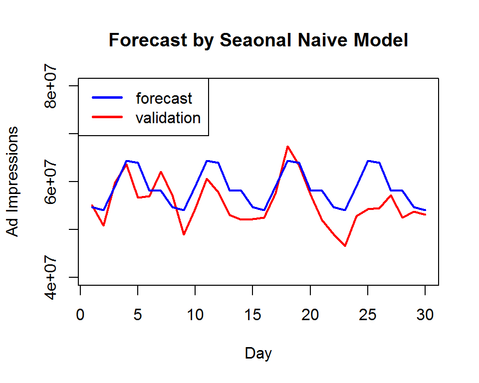

Performance on validation set:

```
## RMSPE: 0.088249471563876
##  RMSE: 4698785.94462212
```

The `seasonal naive` model seems to work not bad. We’ll use its performance as the *baseline* and see how other models can improve the performence.

##### 2) Linear regression with trend and seasonal dummy variables (day of week)

The second model we tried is a `linear regression` model with seasonal dummy variables (day of week). We’ll experimented with three different versions:

- linear regression with **linear trend**
- linear regression with **quadratic trend**
- linear regression with **cubic trend**

```r
tslm.basic <- function(train,degree=1){
  # Computes a forecast using linear regression and seasonal dummy variables
  #
  horizon <- 30
  l <- nrow(train) + horizon

  # Assume the first data point in train set is day 1, generate new variable weekday
  data <- data.frame(adi=c(train[,1],rep(0,30)),trend=c(1:l),weekday=rep_len((1:7),l))

  # Generate dummy variables based on weekday
  # day_i = 1 if the weekday is i else 0
  for (i in 1:6){
    data[paste('day',i,sep='')] <- ifelse(data$weekday==i,1,0)
  }

  # split the train and validation set
  train <- data[1:nrow(train),]
  val <- data[(nrow(train)+1):l,]

  if (degree==1){
    model <- lm(adi~.-weekday,data=train)
  } else{
    model <- lm(adi~.-weekday-trend+I(trend^degree),data=train)
  }

  fc <- predict(model,val)

  return(fc)
}
```

Forecast:

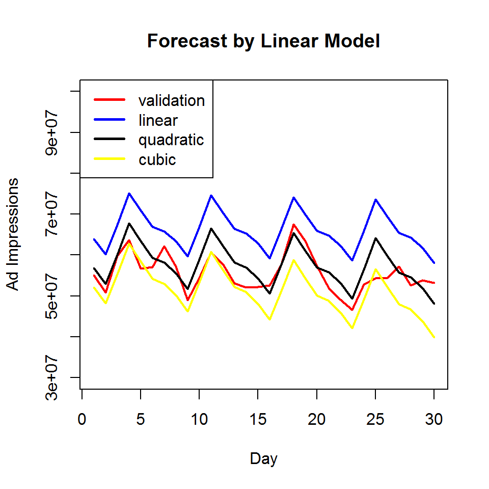

It can be observed that the model with linear and quadratic trend *over estimates* the future, while the one with cubic trend *under estimates* the future. Therefore, it is worthwhile to try to use a *combination* of the two as forecast.

```
## Linear Trend:
##  RMSPE: 0.202042908380177
##  RMSE: 10956640.3811825
```

```
## Quadratic Trend:
##  RMSPE: 0.0708221158211098
##  RMSE: 3888038.72671441
```

```
## Cubic Trend:
##  RMSPE: 0.102409574211307
##  RMSE: 5755223.67417382
```

```
## Average of Quadratic and Cubic Forecast:
##  RMSPE: 0.0656718900361943
##  RMSE: 3724451.31548677
```

We can see the simple average provides a better forecast. The forecast is improved by about 2% compared to the baseline model.

##### 3) SVM regression with trend and seasonal dummy variables (day of week)

The third model is `SVM regressor` with seasonal dummy variables, which is same as linear model. The hyperparmeters are *manually tuned* according to validation set performance.

```r
tslm.svm <- function(train){
  # Computes a forecast using SVM regression and seasonal dummy variables

  horizon <- 30
  l <- nrow(train) + horizon

  # Use the same variables as linear model
  data <- data.frame(adi=c(train[,1],rep(0,30)),trend=c(1:l),weekday=rep_len((1:7),l))
  for (i in 1:6){
    data[paste('day',i,sep='')] <- ifelse(data$weekday==i,1,0)
  }
  train <- data[1:nrow(train),]
  val <- data[(nrow(train)+1):l,]

  # Hyperparameters are tuned manually according to validation set performance
  model <- svm(adi~.,
               data=train,
               cost=3,
               gamma=0.05,
               epsilon=0.0001
               )

  fc <- predict(model,val)

  return(fc)

}
```

Forecast:

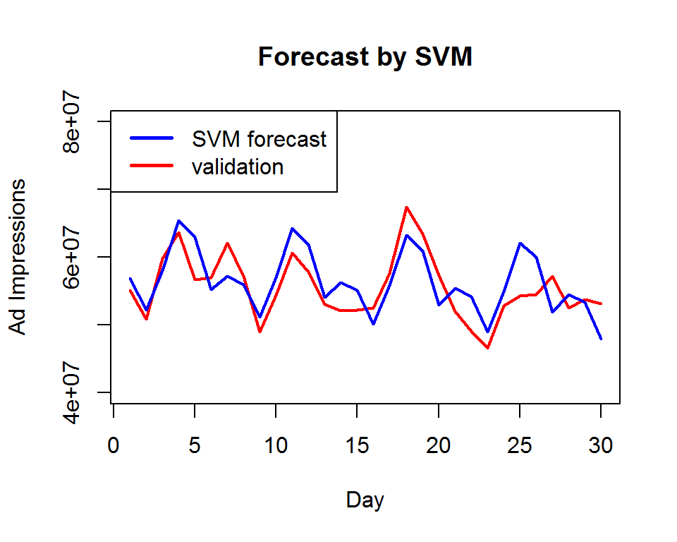

Performance on validation set:

```
## RMSPE: 0.0658927922367868
##  RMSE: 3644381.63411211
```

##### 4) STL decomposition + ETS/Arima

This model performs an STL decomposition on the time series, seasonally adjusts the data, non-seasonally forecasts the seasonally adjusted data using ETS or Arima method.

```r
stl <- function(train,method='ets'){
  # Computes the forest using stlf() from the forecast package.
  # using an exponential smoothing model (ets) or arima for the non-seasonal forecast.

  horizon <- 30

  # Convert the list of values to time series object, frequency set to 7 to
  # reflect weekly pattern
  s <- ts(train[, 1],frequency=7)

  if (method=='ets'){
    # stlf() functions gives forecast on the given time series and horizon
    fc <- stlf(s,
             h=horizon,
             s.window="periodic",
             method='ets',
             ic='bic',
             robust=TRUE)
  } else if(method=='arima'){
    fc <- stlf(s,
             h=horizon,
             s.window="periodic",
             method='arima',
             ic='bic',
             robust=TRUE)
  }

  return(as.numeric(fc$mean))
}
```

Forecast:

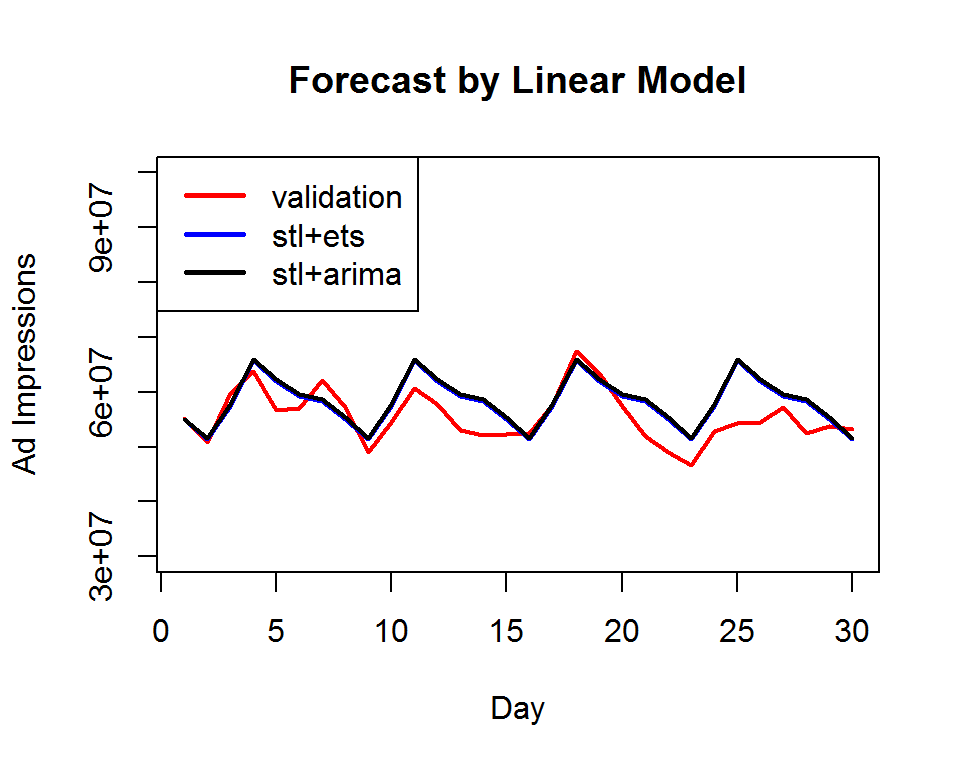

Performance on validation set:

```
## STL+ETS
##  RMSPE: 0.0805570137780204
##  RMSE: 4330292.16419953
```

```
## STL+ARIMA
##  RMSPE: 0.0835022771808811
##  RMSE: 4482423.18378286
```

The performance is barely bettern than the baseline model.

##### 5) ARIMA model

With the ARIMA model, we’ll use the `auto.arima` function in `forecast` package, which conducts a search over possible model and returns the best.

```r
seasonal.arima <- function(train){
  horizon <- 30
  s <- ts(train[, 1],frequency=7)
  model <- auto.arima(s,
                      ic='bic',
                      seasonal.test='ch',
                      seasonal=TRUE)
  fc <- forecast(model, h=horizon)

  return(as.numeric(fc$mean))
}
```

Forecast:

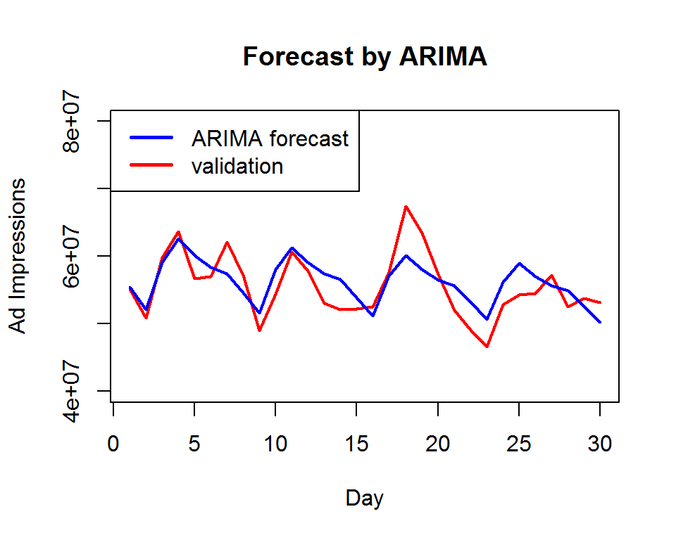

Performance on validation set:

```
## RMSPE: 0.056497723500994
##  RMSE: 3165083.82980718
```

#### 3. Final Model

By far, the `ARIMA` model is the best performance single model. Ideally, we want to test our model performance based on **cross-validation**. However, due to lack of data, we are only validating our model on a fixed validation set. It is likely we are **overfitting** the validation set. As the solution, an `ensemble` approach is desired in order to make the forecast more **robust**.

For the choice of ensemble component, I decided to use the three best performence single models:

- Average of `linear model w/ quadratic trend` and `linear model w/ cubic trend`.
- `SVM regression` with trend and seasonal dummy variables
- `ARIMA` model

```r
ensemble.forecast <- function(train){
  # Computes the first ensemble: ensemble of two tslm models
  tslm.avg <- (tslm.basic(train,2)+tslm.basic(train,3))/2

  # The final ensemble: a unweighted average of the three models
  fc <- (tslm.avg + tslm.svm(train) + seasonal.arima(train))/3

  return(fc)
}
```

Forecast:

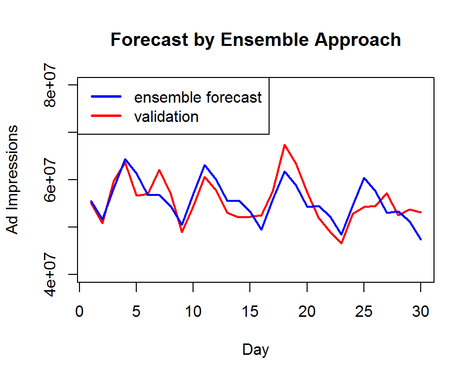

```
## RMSPE: 0.0564250495664832
##  RMSE: 3187449.96744918
```

As we can see, RMSPE is slightly approved compared to ARIMA model, RMSE is a little big higher.

### IV. Final Forecast

Overall, the ensemble approach’s performance on the validation set is very close to the ARIMA model.

However, if we have more test set, it is likely to see the enemble approach should have a more robust performance.

Therefore, I use the ensemble approach as my final forecast.

```
## The forecasts are:
```

```
##      366      367      368      369      370      371      372      373
## 55585378 51661410 58263838 64447510 61351579 56781846 56768364 54487957
##      374      375      376      377      378      379      380      381
## 50596112 57034034 63106850 60112056 55539223 55614619 53413792 49532107
##      382      383      384      385      386      387      388      389
## 55817687 61787667 58890032 54312554 54472408 52346023 48467793 54613193
##      390      391      392      393      394      395
## 60487872 57683672 53100344 53340275 51283579 47402721
```

### V. Potential Improvements

Here are some potential improvements I can think of:

1. There is no date information. Therefore, the holidays information cannot be utlized in the time series model.
2. There is a big drop in the middle of the year. Also the first day’s ad impression is very low. Date and other information is desired to see if they are outlier.